# Capstone Data Analytics

Michael

2023-12-20

## Reading the CSV files

First we need to open the files needed for data analysis.

```r
daily_activity <- read.csv("dailyActivity_merged.csv")
weight_log_info <- read.csv("weightLogInfo_merged.csv")
```

## Package install

Here I am installing the packages for the project.

```r
#install.packages("here")

#install.packages("skimr")

#install.packages("janitor")

#install.packages("dplyr")

#install.packages("ggplot2")
```

## Opening Libraries

Here I am opening the libraries I have installed

```r
library("here")

library("skimr")

library("janitor")

library("dplyr")

library("ggplot2")
```

## Cleaning the files

Next we have the steps I used to clean the files

```r
skim_without_charts("daily_activity")
```

Data summary

| Name | “daily_activity” |
| --- | --- |
| Number of rows | 1 |
| Number of columns | 1 |
| _______________________ |  |
| Column type frequency: |  |
| character | 1 |
| ________________________ |  |
| Group variables | None |

**Variable type: character**

| skim_variable | n_missing | complete_rate | min | max | empty | n_unique | whitespace |
| --- | --- | --- | --- | --- | --- | --- | --- |
| data | 0 | 1 | 14 | 14 | 0 | 1 | 0 |

```r
skim_without_charts("weight_log_info")
```

Data summary

| Name | “weight_log_info” |
| --- | --- |
| Number of rows | 1 |
| Number of columns | 1 |
| _______________________ |  |
| Column type frequency: |  |
| character | 1 |
| ________________________ |  |
| Group variables | None |

**Variable type: character**

| skim_variable | n_missing | complete_rate | min | max | empty | n_unique | whitespace |
| --- | --- | --- | --- | --- | --- | --- | --- |
| data | 0 | 1 | 15 | 15 | 0 | 1 | 0 |

## First plot graph

Next we have a grapgh showing how weight in pounds increases your BMI and and how that effects Bellabeat’s trends that apply to all customers.

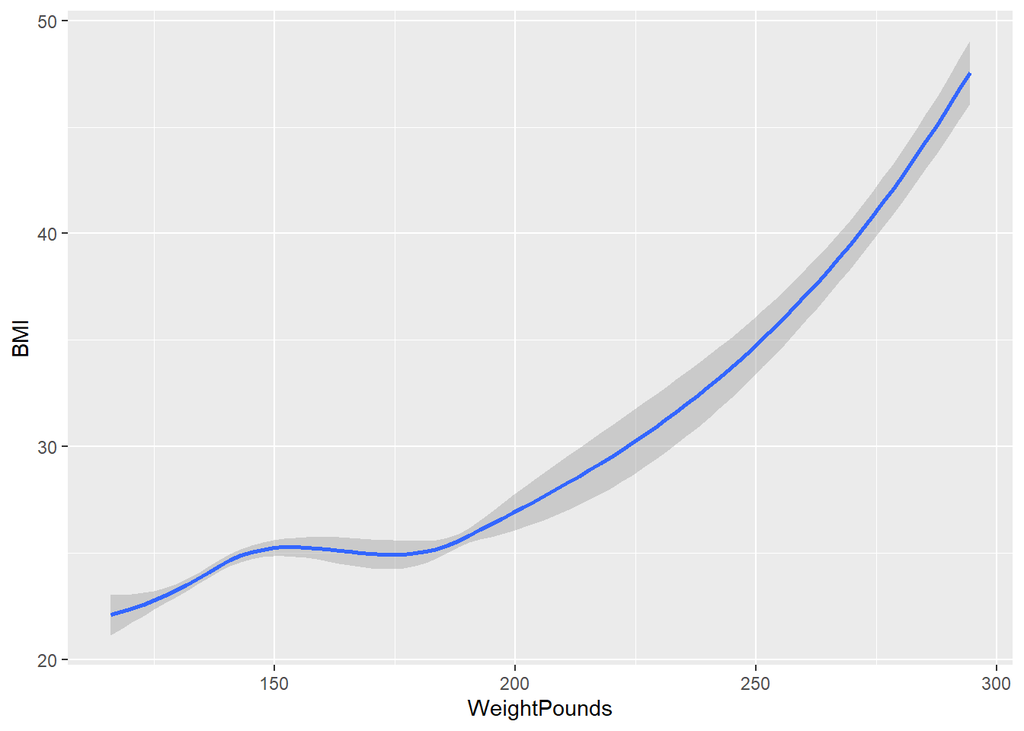

```r
ggplot(data = weight_log_info)+
  geom_smooth(mapping = aes(x = WeightPounds, y = BMI))
```

Here we can see that the more pounds you weigh the higher your BMI is.

## Second Plot Graph

Here we see that the more total steps you take the more calories you should be losing.

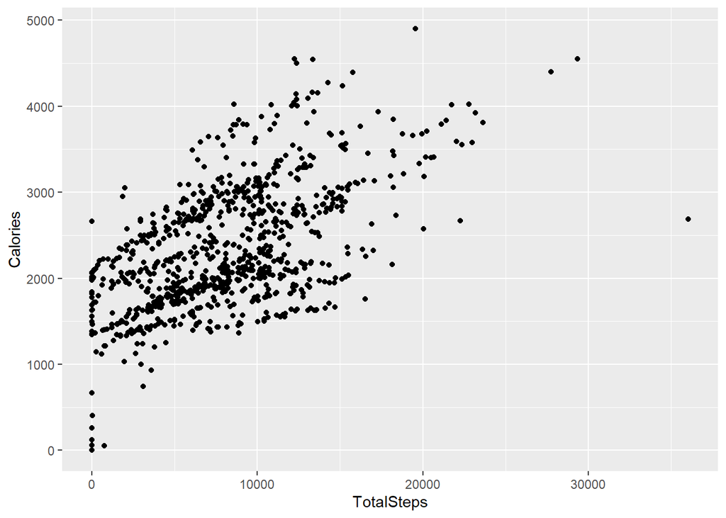

```r
ggplot(data = daily_activity) +
  geom_point(mapping = aes(x = TotalSteps , y = Calories ))
```

This graph shows us the trends of the smart device usage such as the more steps you take the more calories you will burn. Overall this shows us that if we have notifications for users to keep walking they can reach thier weight goals much more effectively.

## Third & Final Graph

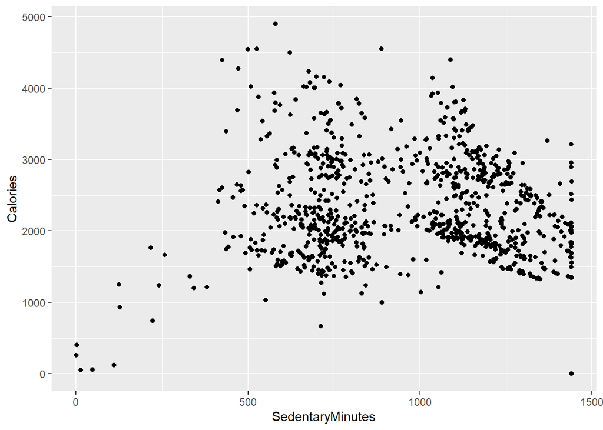

```r
ggplot(data = daily_activity)+
  geom_jitter(mapping = aes(x = SedentaryMinutes, y = Calories ))
```